# Time Series Simulation Study

In this notebook you make a simulation study to investigate the class of ARMA models. You will see that this class of models is

- easily applicable with the `statsmodel` package,
- can be used for simulation of time series data,
- showing good forecasting abilities.

At the end of this notebook you will have learned:

- how to simulate time series data,
- how to define, estimate and forecast with ARMA and SARIMA models,
- how to decompose a time series into a trend, seasonality and rest,
- how to define Exponential Smoothing estimators and apply them to the data for forecasting,
- how to apply stationarty tests and
- how to apply ACF, PACF and Periodogram plots for model diagnosis.

## Load packages

```python
import numpy as np
import pandas as pd
import warnings
import matplotlib.pyplot as plt
import statsmodels.api as sm
from statsmodels.tsa.stattools import kpss
from statsmodels.tsa.stattools import adfuller
from scipy import signal
%matplotlib inline

# If you want a style choose one
#plt.style.use('Solarize_Light2')
#plt.style.use('tableau-colorblind10')
NF_ORANGE = '#ff5a36'
NF_BLUE = '#163251'
```

See all matplotlib styles under [matplotlib styles](https://problemsolvingwithpython.com/06-Plotting-with-Matplotlib/06.13-Plot-Styles/)

## Define auxiliary functions

The following functions are defined to simplify time series plotting, time differencing and stationarity testing. We will use them through this notebook.

```python
def plot_ts(ts = None, ts_add = None, title ='Time Series', legend=['1']):
    """
    Plots one or two time series in a single plot

        Args:
        ts: 1d- or 2d-array of time series. Dimension
            must be (n,) or (n,2)
        title: Title for the time plot.
        legend: list of legend names. If empty no legend.

        Returns:
        matplotlib plot object
    """
    plt.figure(figsize=(10, 4))
    plt.plot(ts[:,], color=NF_ORANGE)
    plt.grid(True,axis='y')
    plt.title(title)
    if ts_add is not None:
        plt.plot(ts_add, color=NF_BLUE)
    if len(legend) > 0:
        plt.legend(legend)
    plt.show()

def plot_acf_pacf(ts, lags=10, layout='h'):
    """
    Plots the empirical ACF and PACF of a time series process.

        Args:
        ts: array of time series

        Returns:
        matplotlib subplot with ACF and PACF
    """
    if layout == 'h':
        fig, ax = plt.subplots(1, 2, figsize = (10,3))
    else:
        fig, ax = plt.subplots(2, 1, figsize = (10,3))
    sm.tsa.graphics.plot_acf(ts,color = NF_ORANGE,lags=lags, ax = ax[0])
    sm.tsa.graphics.plot_pacf(ts,color = NF_ORANGE, lags = lags, ax = ax[1])


def diff_series(ts, interval=1):
    """
    Differences a time series by a certain lag.

        Args:
        ts: array of 1d time series

        Returns:
        Differenced time series
    """
    diff = ts[interval:] - ts[:-interval]
    return diff

def kpss_test(ts):
    """
    Performs a KPSS test for the null hypothesis of stationarity.

        Args:
        ts: 1d time series

        Returns:
        Summary of test statistic and critical values
    """
    print ('Results of KPSS Test:')
    kpsstest = kpss(ts, regression='c', nlags='legacy')
    kpss_output = pd.Series(kpsstest[0:3], index=['Test Statistic','p-value','Lags Used'])
    for key,value in kpsstest[3].items():
        kpss_output['Critical Value (%s)'%key] = value
    print (kpss_output)

def adf_test(ts):
    """
    Performs a Dickey-Fuller test for the null hypothesis of
    non-stationarity.

        Args:
        ts: 1-d time series

        Returns:
        Printed test statistic and critical values.
    """
    print ('Results of Dickey-Fuller Test:')
    dftest = adfuller(ts, autolag='AIC')
    dfoutput = pd.Series(dftest[0:4], index=['Test Statistic','p-value','#Lags Used',
                                             'Number of Observations Used'])
    for key,value in dftest[4].items():
        dfoutput['Critical Value (%s)'%key] = value
    print(dfoutput)
```

## Trend and seasonality

As already mentioned in lecture, trends and seasonalities make a time series process non-stationary as they induce time-dependent distributions, i.e. values of $X_t$ occurring between $t$ and $t+h$ are differently distributed than values between times $t+k$ and $t+k+h$. In such cases the standard theory cannot be applied as stationary processes are assumed in this theory.

It therefore needs a detrending and removing of seasonal components. In the following we consider (1) the composition of time series by a trend a seasonal component and a time-independent dynamic process. For this reason we sample data from a normal distribution (our white noise) and define two trend functions

$$ \begin{align} m_t&=\alpha_1+\alpha_2\cdot t\\ m_t&=\beta_1+\beta_2\cdot t + \beta_3\cdot t^2\\ \end{align} $$

that we add to the white noise.

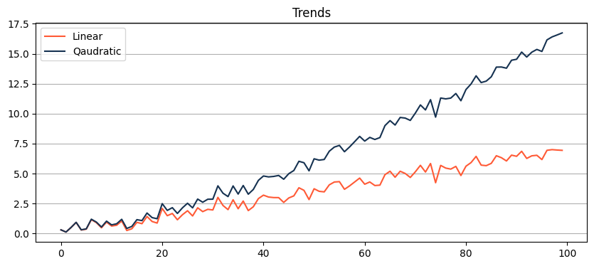

```python
# Define a DGP with a linear and quadratic trend
np.random.seed(42)

# Sample a normal white noise
y = np.random.normal(0.0, 0.4, 100)

# Construct the time series with linear and quadratic trend
trend = 0.1 + 0.07 * np.arange(0,100)
y_ln = trend + y
y_qd = y_ln + 0.001 * np.arange(0,100)**2

# Plot the series
plot_ts(y_ln, y_qd, title = 'Trends', legend=['Linear', 'Qaudratic'])
```

### Estimate a quadratic trend

You learned that there are two methods to eliminate the trend in a time series. The first was estimating it and eliminate this estimate from the original time series. The other method is time differencing. In what follows we use the first method to eliminate the trend from the time series.

We define a white noise process with 300 observations and compose a time series process by a qaudratic trend component with parameters $\alpha_1=0.2$, $\alpha_2=0.01$ and $\alpha_3=0.001$ and let the innovations be white noise normally distributed.

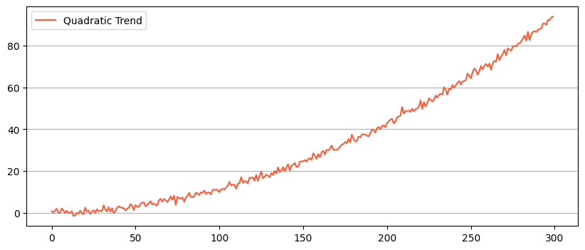

```python
# Define the data generating process
np.random.seed(42)
error = np.random.normal(0.0, 1.1, 300)
trend = 0.2 + 0.01 * np.arange(1, 301) + 0.001 * np.arange(1, 301)**2
y = trend + error

# Plot the time series
plot_ts(y,title='', legend=['Quadratic Trend'])
```

How can we estimate this trend? The most obvious approach is to use OLS with polynomial features in $t$:

$ x_t=\alpha_1+\alpha_2 t + \alpha_3 t^2 $

to estimate the coefficients $\alpha_i~,i=1,2,3$.

```python
# Estimate a linear regression model

# Start by constructing a time index variable and its square
X = np.array([np.arange(1, 301),np.arange(1, 301)**2]).T

# Use a constant term in the OLS regression
X = sm.tools.tools.add_constant(X)
model = sm.OLS(y, X)
res = model.fit()
print(res.summary())
```

```
                            OLS Regression Results
==============================================================================
Dep. Variable:                      y   R-squared:                       0.999
Model:                            OLS   Adj. R-squared:                  0.998
Method:                 Least Squares   F-statistic:                 9.889e+04
Date:                Fri, 31 May 2024   Prob (F-statistic):               0.00
Time:                        14:32:21   Log-Likelihood:                -448.09
No. Observations:                 300   AIC:                             902.2
Df Residuals:                     297   BIC:                             913.3
Df Model:                           2
Covariance Type:            nonrobust
==============================================================================
                 coef    std err          t      P>|t|      [0.025      0.975]
------------------------------------------------------------------------------
const         -0.0377      0.189     -0.200      0.842      -0.409       0.334
x1             0.0131      0.003      4.522      0.000       0.007       0.019
x2             0.0010   9.32e-06    106.446      0.000       0.001       0.001
==============================================================================
Omnibus:                        4.295   Durbin-Watson:                   2.167
Prob(Omnibus):                  0.117   Jarque-Bera (JB):                4.613
Skew:                           0.156   Prob(JB):                       0.0996
Kurtosis:                       3.521   Cond. No.                     1.22e+05
==============================================================================

Notes:
[1] Standard Errors assume that the covariance matrix of the errors is correctly specified.
[2] The condition number is large, 1.22e+05. This might indicate that there are
strong multicollinearity or other numerical problems.
```

Surprisingly, the constant term is highly non-significant and with a farout estimate. However, the coefficients for the time index and its square are near the true values of $[0.01, 0.001]$. To see, if the predictions are good enough we plot the time series together with the estimated function.

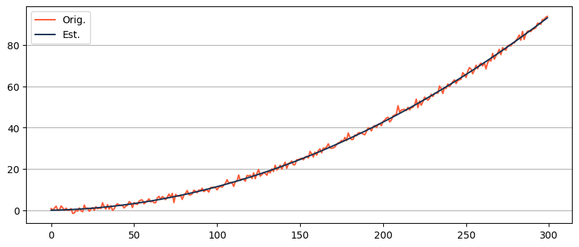

```python
# Plot the original and estimated time series
y_est = res.predict(X)
plot_ts(y, y_est, title='', legend=['Orig.', 'Est.'])
```

That appears to be a good estimate of the quadratic trend immanent in the time series.

> **Exercise**: Take the original time series and difference the estimated one. Plot your results. What do you see?

### Seasonality

Next to trends, seasonality has an influence on the distribution(s) of a time series, as seasonality implies that at certain times the process explores other value ranges than at others. This again would be a non-stationary setting and would make the standard theory for time series modeling to fail.

By eliminating seasonalities (any cyclical pattern) from the time series data such a non-stationary time process can be transformed to a stationary one. Similar to trend elmination also seasonalities can be removed by two main approaches: (1) modeling the cyclical pattern and removing an estimate of this model from the original time series or (2) differencing the original time series at periodical time indices (e.g. a quarterly cyclical pattern has been finished after 4 time steps if data is quarterly),

$ \Delta(4)x_t=x_t-x_{t-4}~. $

In the following we model the cyclical pattern by a *Fourier Series* with a single sinus function and period 60 (e.g. 60 days).

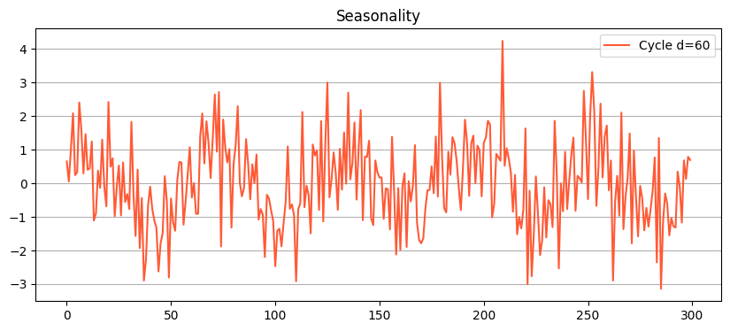

```python
# Define the DGP
np.random.seed(42)

# Define the white noise process
error = np.random.normal(0.0, 1.1, 300)

# Define the seasonal pattern
# Use Fourier Series with a single sinus pattern
# with period 60.
seasonal = np.sin((2*np.pi/60)*np.arange(1,301))

# Combine the two terms and plot the series
y = seasonal + error
plot_ts(y, title = 'Seasonality',legend=['Cycle d=60'])
```

The cyclical pattern in the time series can be seen clearly. It is also easy to detect that the period of the cyclical pattern is 60 as after 60 time steps the process has arrived at a similar level as where it was before 60 steps.

> **Exercise**: Model a cyclical pattern by an OLS equation using sinusoidal function of the time. Estimate this model and plot it together with the original time series process seen above. If the estimate is good enough in your eyes, difference this estimate from the original time series and plot the remaining term.

#### Trend and seasonal component

What we usually observe or encounter in time series is a mixture of both, i.e. some trend and some cyclical pattern (sometimes not even easily detectable). In the following we generate a time series with such properties and you will decompose the model into its different components, i.e. (1) trend, (2) seasonal, and (3) residuals. Residuals might show no white noise properties (e.g. autocorrelation) and that would then need to be modeled as well (e.g. with an ARMA model).

In the following you create a time series with a normally distributed innovation vector together with a sinuoidal seasonal pattern and a linear trend.

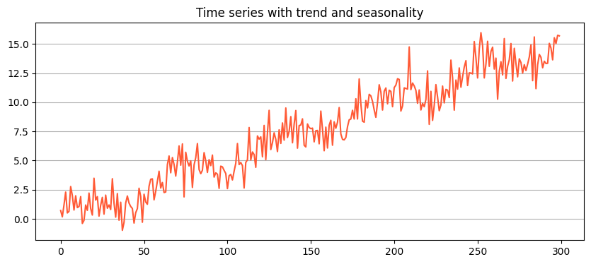

```python
# Generate the data with trend and seasonal component
np.random.seed(42)

# Define the white noise process
error = np.random.normal(0.0, 1.1, 300)

# Define the seasonal term
seasonal = np.sin((2*np.pi/60)*np.arange(1,301))

# Define the trend component
trend = 0.01 + 0.05 * np.arange(1, 301)

# Add all components together and plot them
y = trend + seasonal + error
plot_ts(y, title='Time series with trend and seasonality', legend=[])
```

This looks already like time series we might observe in the news or in business. As the decomposition is part of time series EDA, there exist pre-defined functions to decompose time series into their three components. In the `statsmodels` module the function `tsa.seasonal_decompose()` can be used to make such a decomposition. For the cyclical component you have to define a period length. (Take also a look at the multiplicative version of it).

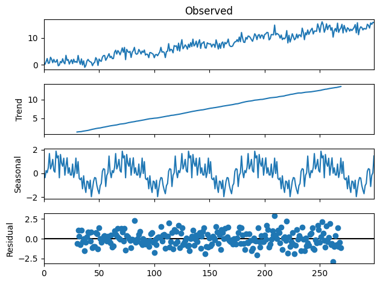

```python
# Decompose the time series into trend, seasonal component and residuals
y_dec = sm.tsa.seasonal_decompose(y, model = 'additive', period=60)
y_dec.plot()
plt.show();
```

The residuals show white noise behavior. And to see, if residuals have really no autocorrelations, we could do some diagnostic checks and tests.

> **Exercise**: For the residuals process from the decomposition in `y_dec`. Plot the ACF and PACF. Take also a look at the [*Ljung-Box-Test*](https://www.statsmodels.org/stable/generated/statsmodels.stats.diagnostic.acorr_ljungbox.html) and apply this test to your residuals.

#### Example with a composed model

Remember: any stationary zero-mean time series can be expressed as a harmonic sum of (infinitely many) sinus and cosinus waves (very seldom this sum is finite - therefore modeling with such a harmonic mean a whole time series is avoided). The periodicity $d$ of a seasonal trend then determines the rate at which a cycle is finished in one time step:

$\frac{2\pi}{d}t$

We can also say $\frac{1}{d}$ is the frequency of the cycle, i.e. if $d=4$ a quarter of the whole cycle is concluded at a single time step. Trigonometrically, the cycle concludes $0.25\cdot2\pi$ *radiants* per time step and a whole cycle after 4 time steps.

In the following simulation we model the seasonal component as a Fourier Series with a single sinus function and a periodicity of 4. A linear trend is added ogether with an AR(2) process. Note that in this case the white noise is generated inside of the `generate_sample()` method. The innvoation term $\varepsilon$ therewith is white noise, however, the residuum of a time series decomposition will be not, as this process is then an AR(2) process such that residuals from the time decomposiion would be autocorrelated (the Ljung-Box test can be applied here).

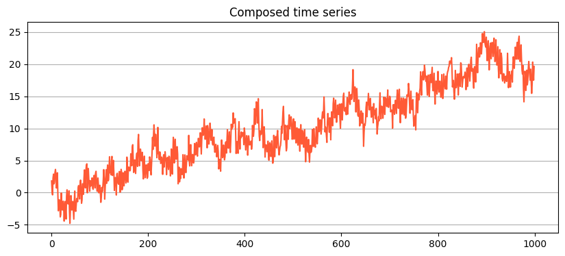

```python
# Generate an AR(2) process
np.random.seed(42)
ar_proc = sm.tsa.ArmaProcess(ar = [1, -.7, -.2]).generate_sample(nsample=1000)

# Define trend and seasonal component
seasonal = 1.3 * np.sin(2*np.pi/4*np.arange(1,1001))
trend = 0.01 + 0.02 * np.arange(1, 1001)
y = trend + ar_proc + seasonal
plot_ts(y,legend=[],title='Composed time series')
```

You can see that the cycle is somehow still apparent, even though it got washed out a little by the AR(2) component.

In a real-world time series approach the first step after looking at the graph above, would be a trend elimination. This time we use the second method for trend removal, i.e. the time differencing approach:

$ \Delta x_t=x_t - x_{t-1}~. $

Time differencing works well, if the trend is linear. With a non-linear trend we usually have to difference multiple times to arrive at a stationary process.

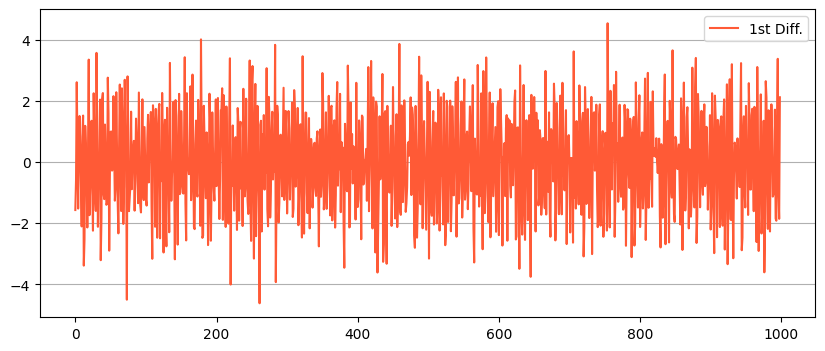

```python
# Detrend the series
y_diff = diff_series(y)
plot_ts(y_diff, title = '', legend=['1st Diff.'])
```

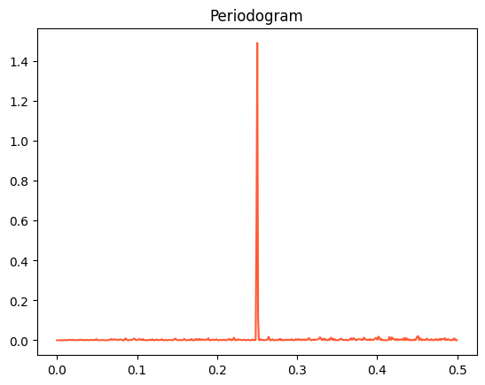

```python
# We use for the sampling frequency 1 as we want to
# discover cycles over the original time steps.
f, Pxx = signal.periodogram(y_diff, fs = 1, window='hamming', scaling='spectrum')
plt.plot(f, Pxx, color = NF_ORANGE)
plt.title('Periodogram')
plt.show();
```

The dominant frequency here identified by the periodogram lays at around $\frac{1}{d}=0.25$ which corresponds to a periodicity of $d=4$, exactly the periodicity of the simulated seasonality. We can also observe that there exist many more cyclical patterns with other frequencies (observe the little trembling along the line), however the one at frequency 0.25 is the by far most dominant one. By using the periodogram we can identify what frequencies are included in our time series and which are the most dominant ones. By eliminating the most dominant ones we arrive at some point at a stationary time series that allows us explicit modeling via an ARMA model for example.

As the periodicity in our time series appears to be at 4 (identified by the periodogram), we clean our series from this cyclical pattern by taking a difference between the actual value and its lag four time periods before:

$ \Delta(4) x_t=x_t-x_{t-4}~. $

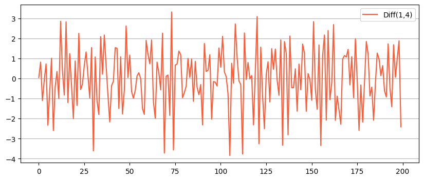

```python
# Difference the time series and plot
y_diff_4 = diff_series(y_diff, 4)
plot_ts(y_diff_4[:200,], title='', legend=['Diff(1,4)'])
```

From the graph it appears that the dominant cycle which was clearly visual has been removed from the series. If this is the case should be checked by a periodogram on the cleaned time series and also a stationarity test. We look at such stationarity tests in the next section.